# My First Segmentation with keras

At a competition level, you should focus on more robust architectures, like UNet.

## Data

This dataset contains a large number of car images (as .jpg files). **Each car has exactly 16 images, each one taken at different angles. Each car has a unique id and images are named according to id_01.jpg, id_02.jpg ... id_16.jpg. In addition to the images, you are also provided some basic metadata about the car make, model, year, and trim.**

For the training set, you are provided a .gif file that contains the manually cutout mask for each image. The competition task is to automatically segment the cars in the images in the test set folder. To deter hand labeling, we have supplemented the test set with car images that are ignored in scoring.

The metric used to score this competition requires that your submissions are in run-length encoded format. Please see the evaluation page for details, and train_masks.csv for a real example of what the encoding looks like.

## File descriptions

- /train/ - this folder contains the training set images
- /test/ - this folder contains the test set images. You must predict the mask (in run-length encoded format) for each of the images in this folder
- /train_masks/ - this folder contains the training set masks in .gif format
- train_masks.csv - for convenience, this files gives a run-length encoded version of the training set masks.
- sample_submission.csv - shows the correct submission format
- metadata.csv - contains basic information about all the cars in the dataset. Note that some values are missing.

## Submission File

In order to reduce the submission file size, our metric uses run-length encoding on the pixel values. Instead of submitting an exhaustive list of indices for your segmentation, you will submit pairs of values that contain a start position and a run length. E.g. '1 3' implies starting at pixel 1 and running a total of 3 pixels (1,2,3).

The competition format requires a space delimited list of pairs. For example, '1 3 10 5' implies pixels 1,2,3,10,11,12,13,14 are to be included in the mask. The metric checks that the pairs are sorted, positive, and the decoded pixel values are not duplicated. The pixels are numbered from top to bottom, then left to right: 1 is pixel (1,1), 2 is pixel (2,1), etc.

```python
import numpy as np
import pandas as pd
import matplotlib.pyplot as plt
from skimage.io import imread
from skimage.transform import downscale_local_mean
import os, tqdm, cv2

from sklearn.model_selection import train_test_split

Input_Folder = "../input"
df_mask = pd.read_csv(os.path.join(Input_Folder, 'train_masks.csv'), usecols=['img'])
ids_train = df_mask['img'].map(lambda s: s.split('_')[0]).unique()
imgs_idx = list(range(1, 17))

load_img = lambda im, idx: imread(os.path.join(Input_Folder, 'train', '{}_{:02d}.jpg'.format(im, idx)))
load_mask = lambda im, idx: imread(os.path.join(Input_Folder, 'train_masks', '{}_{:02d}_mask.gif'.format(im, idx)))
resize = lambda im : downscale_local_mean(im, (4,4) if im.ndim==2 else (4,4,1))
mask_image = lambda im, mask: (im * np.expand_dims(mask, 2))
```

```python
num_train = 32 # len(ids_train)

# Load data for position id=1
X = np.empty((num_train, 320, 480, 12), dtype=np.float32)
y = np.empty((num_train, 320, 480, 1), dtype=np.float32)

with tqdm.tqdm_notebook(total=num_train) as bar:
    idx = 1 # Rotation index
    for i, img_id in enumerate(ids_train[:num_train]):
        imgs_id = [resize(load_img(img_id, j)) for j in imgs_idx]
        # Input is image + mean image per channel + std image per channel
        X[i, ..., :9] = np.concatenate([imgs_id[idx-1], np.mean(imgs_id, axis=0), np.std(imgs_id, axis=0)], axis=2)
        y[i] = resize(np.expand_dims(load_mask(img_id, idx), 2)) /255.
        del imgs_id # Free memory
        bar.update()
#Rq: Adding mean, std, and the mask to x_train, is a way to include all rotations images for a particular car.
###  It has important information for background removal (std is very close to zero for common background, see channel 6 to 8).

# Train mask contains very useful information: average is the "bias" term per pixel, std is the decision boundary and min is the region where all masks are present.
```

```python
X_train, X_val, y_train, y_val = train_test_split(X, y, test_size=0.2, random_state=100)

# Concat overall y info to X
# This is important as the kernels of CNN used below has no information of its location
y_train_mean = y_train.mean(axis=0)
y_train_std = y_train.std(axis=0)
y_train_min = y_train.min(axis=0)

y_features = np.concatenate([y_train_mean, y_train_std, y_train_min], axis=2)
X_train[:, ..., -3:] = y_features
X_val[:, ..., -3:] = y_features
```

```python
# Normalize input and output
X_mean = X_train.mean(axis=(0,1,2), keepdims=True)
X_std = X_train.std(axis=(0,1,2), keepdims=True)

X_train -= X_mean; X_train /= X_std
X_val -= X_mean; X_val /= X_std
```

```python
# Create simple model
from keras.layers import Conv2D
from keras.models import Sequential
import keras.backend as k

model = Sequential()
model.add(Conv2D(16, 3, activation='relu', padding='same', input_shape = (320, 480, 12)))
model.add(Conv2D(32, 3, activation='relu', padding='same'))
model.add(Conv2D(1, 5, activation='sigmoid', padding='same'))

from keras.optimizers import Adam
from keras.losses import binary_crossentropy
smooth = 1.

# From here: https://github.com/jocicmarko/ultrasound-nerve-segmentation/blob/master/train.py
def dice_coef(y_true, y_pred):
    y_true_f = k.flatten(y_true)
    y_pred_f = k.flatten(y_pred)
    intersection = k.sum(y_true_f * y_pred_f)
    return (2. * intersection + smooth) / (k.sum(y_true_f) + k.sum(y_pred_f) + smooth)
def bce_dice_loss(y_true, y_pred):
    return 0.5 * binary_crossentropy(y_true, y_pred) - dice_coef(y_true, y_pred)

model.compile(Adam(lr=1e-3), bce_dice_loss, metrics=['accuracy', dice_coef])
history = model.fit(X_train, y_train, epochs = 15, validation_data=(X_val, y_val), batch_size=5, verbose=1)
```

```
Train on 25 samples, validate on 7 samples
```

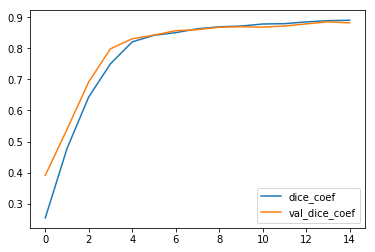

```python
pd.DataFrame(history.history)[['dice_coef', 'val_dice_coef']].plot();
```

```
Text(0.5,1,'y_pred')
```

[figure not shown]

```python
idx = 0
x = X_val[idx]

fig, ax = plt.subplots(5, 3, figsize=(16, 16))
ax = ax.ravel()

cmaps = ['Reds', 'Greens', 'Blues']
for i in range(x.shape[-1]):
    ax[i].imshow(x[..., i], cmap='gray') #cmaps[i%3])
    ax[i].set_title('channel {}'.format(i))

ax[-3].imshow((x[...,:3] * X_std[0,...,:3] + X_mean[0,...,:3]) / 255.)
ax[-3].set_title('X')
ax[-2].imshow(y_train[idx,...,0], cmap='gray')
ax[-2].set_title('y')

y_pred = model.predict(x[None]).squeeze()
ax[-1].imshow(y_pred, cmap='gray')
ax[-1].set_title('y_pred')
```

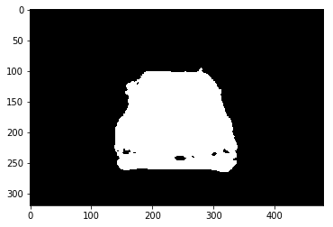

```python
plt.imshow(y_pred > 0.5, cmap='gray');
```